# Лабораторная работа №9

Текстовой редактор emacs

Кузнецова С. В.

Российский университет дружбы народов, Москва, Россия

6 апреля 2023

# Информация

## Докладчик

- Кузнецова София Вадимовна
- студент прикладной информатики
- Российский университет дружбы народов

# Цель

Познакомиться с операционной системой Linux. Получить практические навыки работы с редактором Emacs.

# Выполнение лабораторной работы

## Открытие emacs и создание файла

Ctrl-x Ctrl-f - создание файла.

[figure not shown]

Открытие emacs и создание файла lab07.sh

## Набор текста и сохранение файла

Ctrl-x Ctrl-s - сохранение файла.

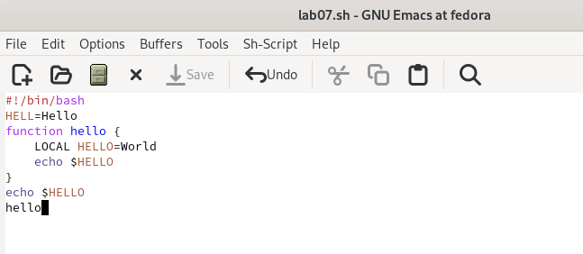

Набор текста и сохранение файла

## Выполнение стандартных процедур редактирования

1. Ctrl-k - вырезать целую строку.
2. Ctrl-y - вставить строку в конец файла.
3. Ctrl-space - выделить область текста.
4. Alt-w - копировать в буфер обмена
5. Ctrl-y - вставить область в конец файла.
6. Ctrl-space - выделить область текста.
7. Ctrl-w - вырезать область текста.
8. Ctrl-/ - отменить последнее действие.

## Выполнение стандартных процедур редактирования

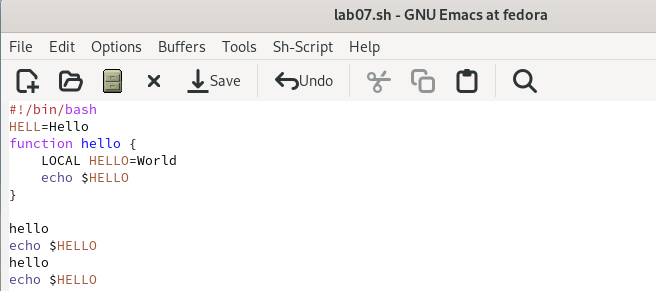

Стандартные процедуры редактирования с помощью комбинаций клавиш

## Команды по перемещению

1. Перемещения курсора в начало строки Ctrl-a, в конец строки Ctrl-e.
2. Перемещение курсора в начало буфера Alt-<, в конец буфера Alt->.

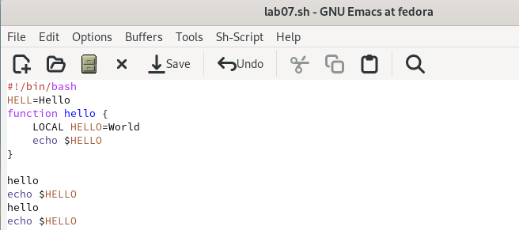

Команды по перемещению

## Управление буферами

1. Ctrl-x Ctrl-b - вывести список активных буферов на экран.
2. Ctrl-x - переместиться во вновь открытое окно.
3. Ctrl-x 0 - закрыть это окно.

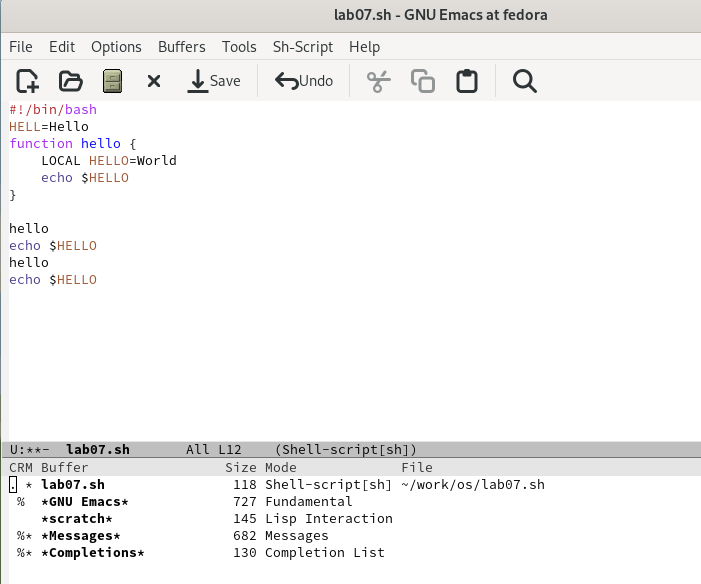

Управление буферами

## Управление окнами

1. Ctrl-x 3 - разделить фрейм на два окна по вертикали.
2. Ctrl-x 2 - разделить каждое из этих окон на две части по горизонтали.

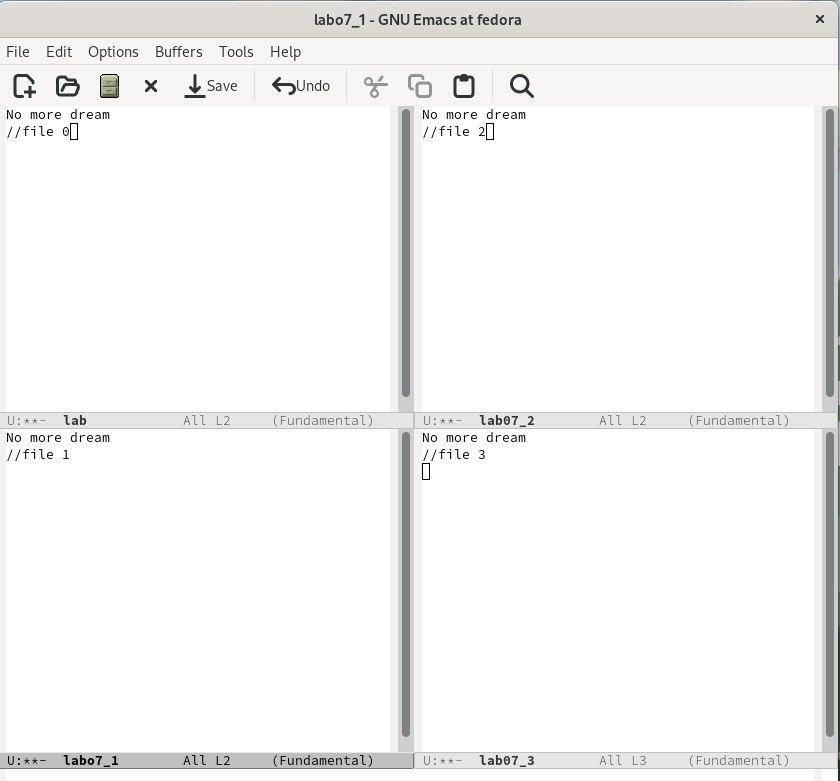

Управление окнами

## Работа с режимом поиска

1. Ctrl-s - переключиться в режим поиска и также для переключения между результатами поиска.
2. Ctrl-g - выйти из режима поиска.

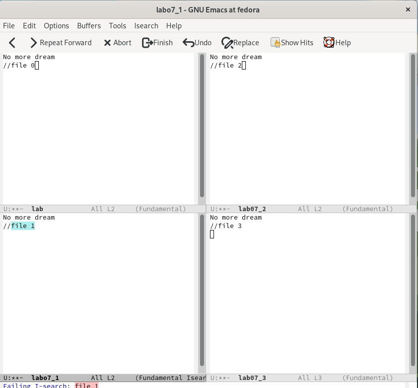

Режим поиска, переключение между результатами, выход из поиска

## Режим поиска и замены

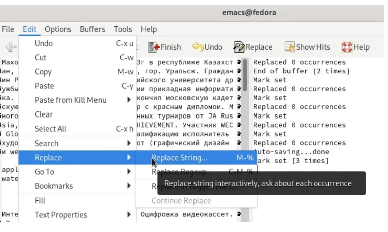

Режим поиска и замены

## Работа с режимом поиска и замены

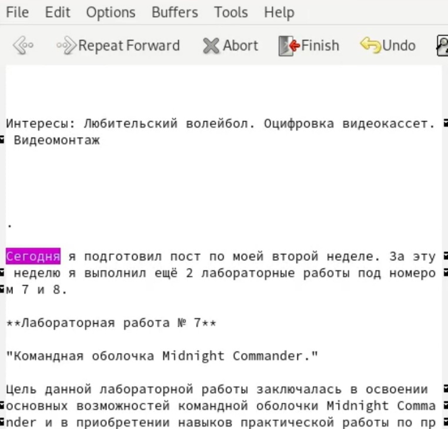

Результаты поиска и замены

## Работа с режимом поиска и замены

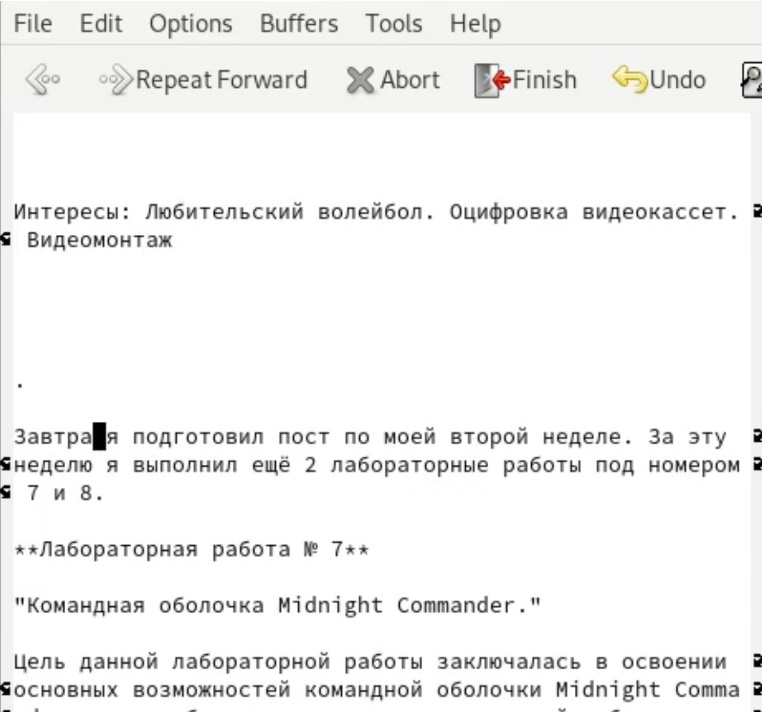

Осуществление замены

## Альтернативный режим поиска

Alt-s o - альтернативный режим поиска.

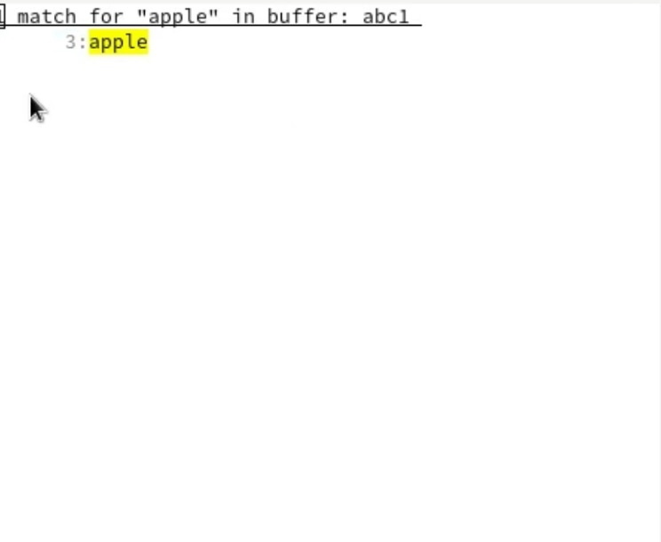

Другой режим поиска

# Вывод

Познакомилась с операционной системой Linux. Получила практические навыки работы с редактором Emacs.